# stats-330-assignment-1

Brett Kim

24 July 2019

### Question (a)

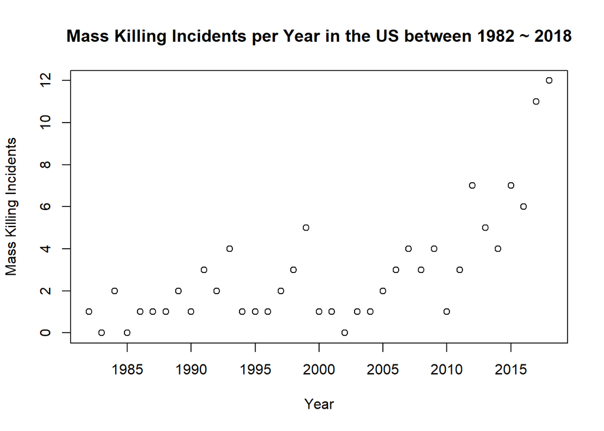

There appears to be an increasing relationship between mass killing incidents and the year. We can also notice that there is greater variability in the number of mass killing incidents as year increases. From this information one could say there is an approximate increasing relationship but not necessarily linear.

### Question (b)

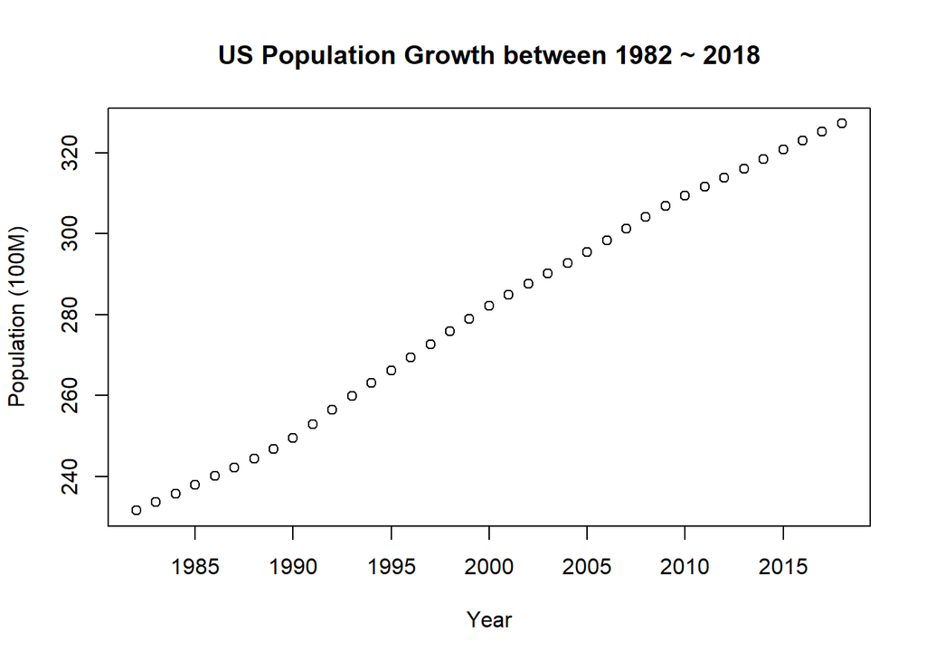

There is a clear linear positive linear relationship between the population of the US and the year. As year increases, population increases at a linear rate.

### Question (c)

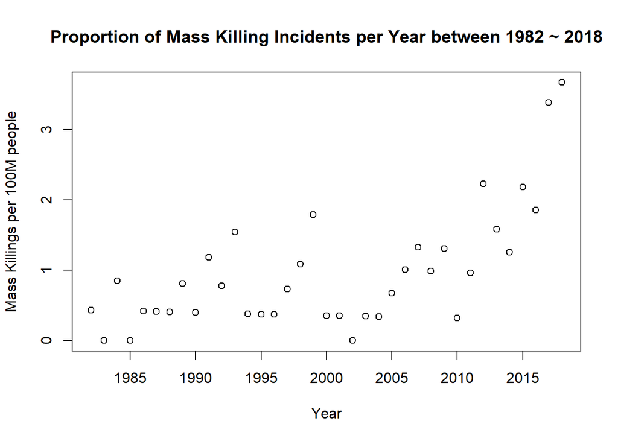

This graph of the proportion of mass killings per 100 million population looks pretty much exactly the same as the mass killing incidents per year graph. There is an increasing relationship between the proportion of kills/100M population and the year, while variance in the proportion increases as year increases.

### Question (d)

```
##
## Call:  glm(formula = masskill ~ I(year - 1982), family = "poisson",
##     data = kill_df, offset = log(popn/100))
##
## Coefficients:
##    (Intercept)  I(year - 1982)
##       -1.26445         0.05832
##
## Degrees of Freedom: 36 Total (i.e. Null);  35 Residual
## Null Deviance:       71.47
## Residual Deviance: 36.44     AIC: 134.4
```

The output of the log of the expected number of mass killings increases by approximately 0.06 per 1 year increase. However, at year 0 (1982) our model predicts that the log of the expected number of mass killings is negative (-1.264) which is not possible.

### Question (e)

Our model is:

$$log(\hat{\mu_i}) = \hat{\beta_0} + \hat{\beta_1}(year_i) + log(\frac{popn}{100})$$

backtransforming this we get:

$$\begin{aligned}
e^{log(\hat{\mu_i)}} &= e^{\hat{\beta_0} + \hat{\beta_1}(year_i) + log(\frac{popn}{100})} \\
\hat{\mu_i} &= e^{\hat{\beta_0}} \times e^{\hat{\beta_1}year_i} \times \frac{popn}{100}
\end{aligned}$$

where:

$$mass \ killings_i \sim Poisson(\hat{\mu_i})$$

### Question (f)

```
##
## Call:  glm(formula = masskill ~ I(year - 1982) + I((year - 1982)^2),
##     family = "poisson", data = kill_df, offset = log(popn/100))
##
## Coefficients:
##        (Intercept)      I(year - 1982)  I((year - 1982)^2)
##          -0.520616           -0.038864            0.002342
##
## Degrees of Freedom: 36 Total (i.e. Null);  34 Residual
## Null Deviance:       71.47
## Residual Deviance: 31.14     AIC: 131.1
```

### Question (h)

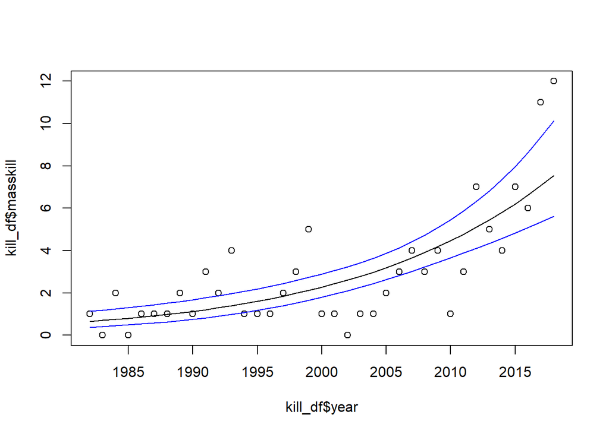

```r
x = glm(formula = masskill ~ I(year-1982), family = "poisson", offset = log(popn/100), data = kill_df)
predictions = predict(x, se.fit = TRUE)

plot(kill_df$year, kill_df$masskill)
lines(x = kill_df$year, y = exp(predictions$fit))
lines(x = kill_df$year, y = exp(predictions$fit - 1.96*predictions$se.fit), col = 'blue')
lines(x = kill_df$year, y = exp(predictions$fit + 1.96*predictions$se.fit), col = 'blue')
```

### Question (i)

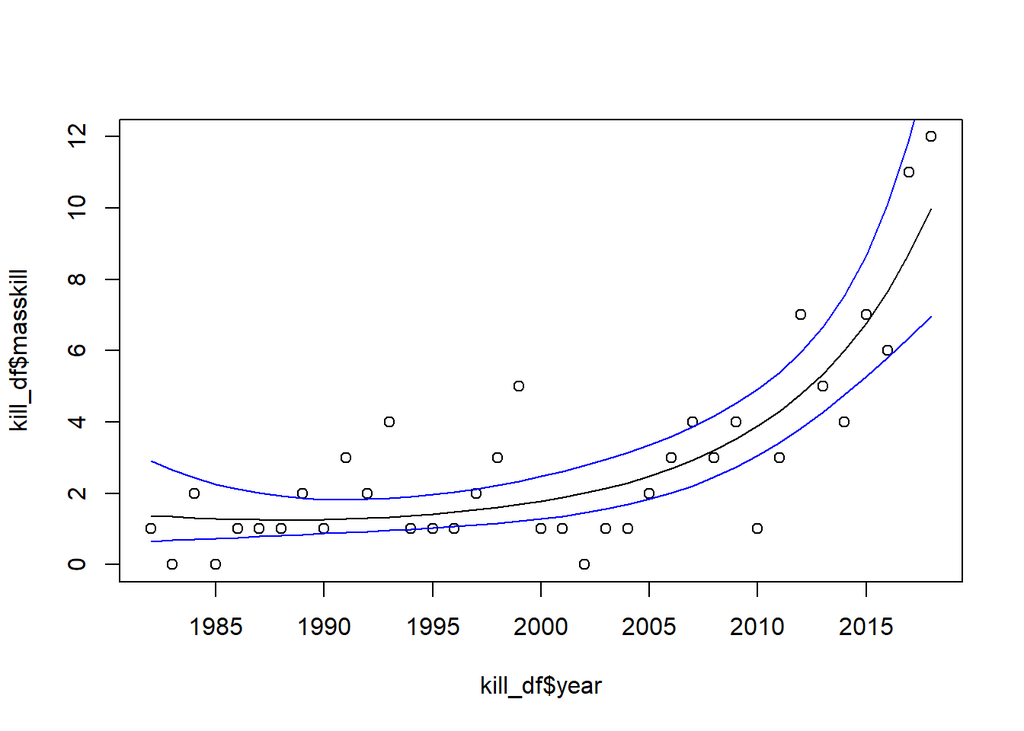

###Question (j)

```r
popn_2019 = 327170000/1000000
x = coef(glm(formula = masskill ~ I(year-1982), family = "poisson", offset = log(popn/100), data = kill_df))

lambda_linear = exp(as.numeric(x[1]))*exp(as.numeric(x[2])*37)*(popn_2019/100)
se_lambda_linear = sqrt(lambda_linear/popn_2019)

print(paste(lambda_linear - 1.96*se_lambda_linear, lambda_linear + 1.96*se_lambda_linear))
```

```
## [1] "7.68837106100238 8.30114745314711"
```

The 95% confidence interval of the mean number of mass killings in 2019 using the linear poisson model is between 7.688 and 8.301.

```r
y = coef(glm(formula = masskill ~ I(year-1982)+I((year-1982)^2), family = "poisson", offset = log(popn/100), data = kill_df))

lambda_quad = exp(as.numeric(y[1]))*exp(as.numeric(y[2])*37)*exp(as.numeric(y[3])*(37^2))*(popn_2019/100)
se_lambda_quad = sqrt(lambda_linear/popn_2019)

print(paste(lambda_quad - 1.96 * se_lambda_quad, lambda_quad + 1.96 * se_lambda_quad))
```

```
## [1] "11.0843678116945 11.6971442038392"
```

The 95% confidence interval of the mean number of mass killings in 2019 using the quadratic poisson model is between 11.084 and 11.697.

### Question (k)

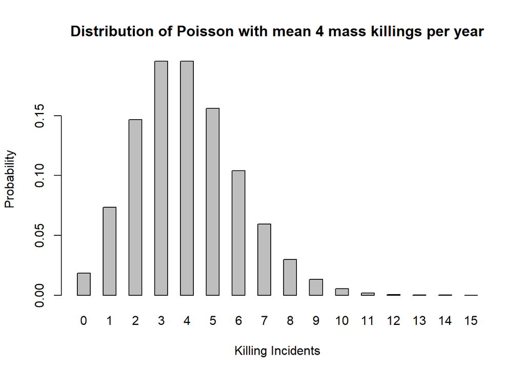

```r
pred.mean.lin = lambda_linear/2
barplot(dpois(0:15, pred.mean.lin),ylab = "Probability", xlab = "Killing Incidents", main = paste("Distribution of Poisson with mean", round(pred.mean.lin,2), "mass killings per year"), space = 1, names.arg = 0:15)
```

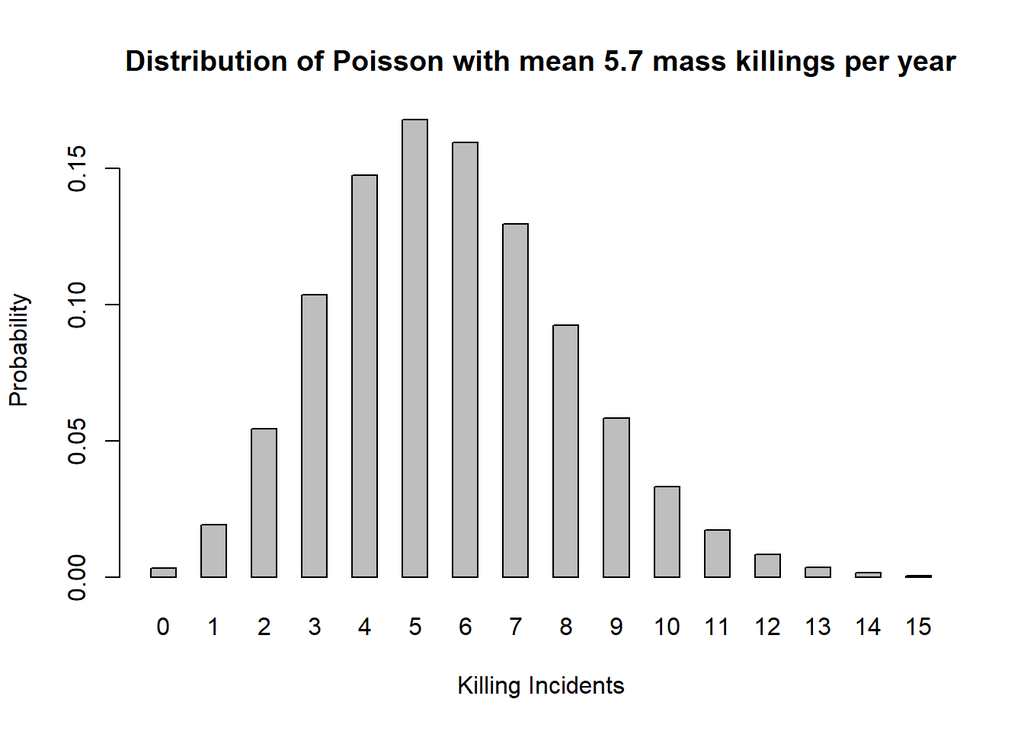

```r
pred.mean.quad = lambda_quad/2
barplot(dpois(0:15, pred.mean.quad),ylab = "Probability", xlab = "Killing Incidents", main = paste("Distribution of Poisson with mean", round(pred.mean.quad,2), "mass killings per year"), space = 1, names.arg = 0:15)
```

From our two distributions it appears that the linear poisson model is the most appropriate given that there have been four mass killing incidents in the first half year of 2019 (January to June). The linear model is more appropriate given this data because it predicts a higher probability of 4 killing incidents compared to the quadratic model.